### **Overview**

Este livro é a típica “Bíblia” sobre um determinado assunto (i.e. Econometria). Não que não existam outros que também possam ser considerados da mesma forma, porém este é o que vejo com frequência sendo recomendado na parte de bibliografias da matéria de econometria de diversos cursos. Neste livro, os autores buscam explicar a modelagem econométrica de maneira simples e completa, partindo da definição dos termos inerentes à área até os modelos um pouco mais complexos. Ao meu ver, este é um livro de nível básico e intermediário, podendo ser lido por quem ainda não conhece nada sobre econometria.

Logo no início, os autores buscam estabelecer um conceito sobre o que é econometria, chegando as seguintes definições:

- **Econometria é a aplicação de estatística a dados econômicos**
- **Econometria é a análise quantitativa de fenômenos econômicos**

Também afirmam que a metodologia econométrica se baseia em (i) estabelecimento de uma hipótese; (ii) especificação de um modelo matemático; (iii) obtenção de dados; (iv) estimativa de parâmetros; (v) teste de hipótese; (vi) validção do modelo.

Neste post (como em todos os posts que estão na categoria **library**), irei resumir os capítulos deste livro e resolver alguns exercícios, visando auxiliar pessoas que estejam lendo ele também, pois poderão encontrar a resolução dos exercícios e também a base de dados usadas no meu repositório do git hub.

[figure not shown]

Capa do livro

### **Cap.1**

#### **A natureza da análise de regressão**

##### **Resumo**

Este é um capítulo introdutório que mostra estabelece alguns pilares da análise de regressão. Primeiro é feito uma definição para o termo regressão, que segundo os autores é *o estudo da dependência de uma variável em relação a uma ou mais variáveis explicativas.* Também tem-se estabelecido o objetivo da regressão, que é estimar o valor médio da variável dependente usando os valores conhecidos da variável explicativa.

Na sequência, os autores mostram a diferença de relações estatísticas e relações determinísticas, mostrando cenários para cada relação e indicando o por quê da regressão ser tão importante para relações estatísticas. Também é indicada a diferença entre regressão e causação e regressão e correlação.

Por fim, os autores comentam sobre os tipos de dados normalmente presentes nos modelos econométricos. Estes dados são **séries temporais** e **corte transversal**.

##### **1.1) Traga os dados da tabela 1.3 sobre o índice de preço ao consumidor (IPC) para responder as alternativas.**

```r
tbl_1.3 <- read.table(file = paste(path,"tabela_1.3_IPC.txt",sep = ""),
                      sep = " ",
                      header = T,
                      dec = ",")

# Amostra aleatória dos dados
tbl_1.3[sample(nrow(tbl_1.3),10), ]
```

|  | Ano | EUA | Canada | Japão | França | Alemanha | Italia | Reino.Unido |
| --- | --- | --- | --- | --- | --- | --- | --- | --- |
| 5 | 1984 | 103.9 | 104.7 | 102.1 | 108.0 | 102.7 | 111.4 | 104.8 |
| 10 | 1989 | 124.0 | 129.3 | 108.0 | 128.7 | 109.2 | 150.7 | 135.4 |
| 11 | 1990 | 130.7 | 135.5 | 111.4 | 132.9 | 112.2 | 160.4 | 148.2 |
| 8 | 1987 | 113.6 | 118.4 | 104.9 | 121.1 | 104.9 | 135.1 | 119.7 |
| 4 | 1983 | 99.6 | 100.4 | 99.8 | 100.3 | 100.3 | 100.8 | 99.8 |
| 15 | 1994 | 148.2 | 148.2 | 119.3 | 145.8 | 131.1 | 195.3 | 169.3 |
| 2 | 1981 | 90.9 | 85.6 | 95.3 | 81.8 | 92.2 | 75.5 | 87.9 |
| 14 | 1993 | 144.5 | 147.9 | 118.5 | 143.4 | 127.6 | 187.7 | 165.3 |
| 13 | 1992 | 140.3 | 145.3 | 117.0 | 140.4 | 122.2 | 179.5 | 162.7 |
| 19 | 1998 | 163.0 | 157.8 | 122.2 | 154.2 | 139.1 | 222.5 | 191.4 |

##### **a) Com base nos dados forneceidos, calcule a taxa de inflação de cada país:**

```r
# Taxa de inflação (1985 = 100, até 2005)
ipc_total <- tbl_1.3 %>%
  filter(Ano %in% c(1985,2005))

ipc_total <- ipc_total[2,2:8]-ipc_total[1,2:8]

knitr::kable(ipc_total, align = "c")
```

|  | EUA | Canada | Japão | França | Alemanha | Italia | Reino.Unido |
| --- | --- | --- | --- | --- | --- | --- | --- |
| 2 | 87.7 | 75.9 | 14.1 | 58.9 | 48.9 | 139.6 | 114.5 |

##### **b) Represente graficamente a taxa de inflação de cada país:**

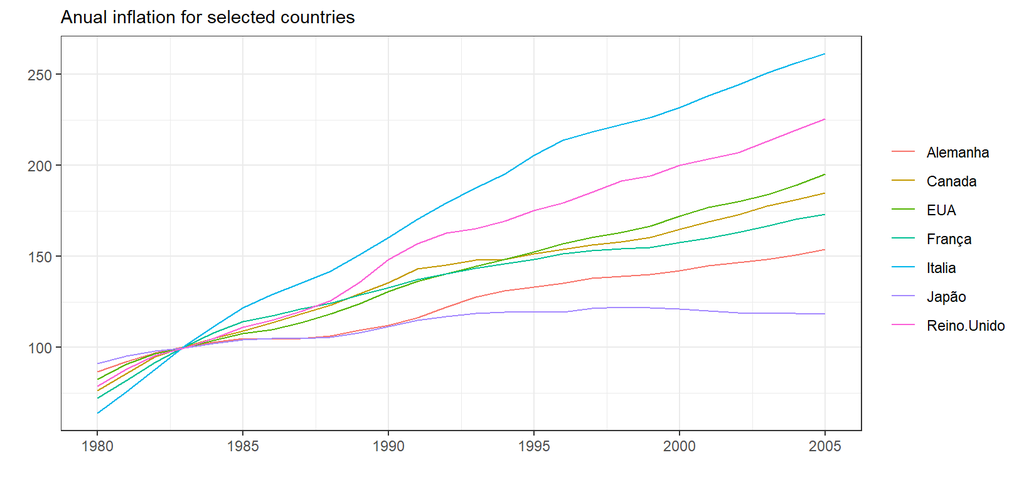

```r
tbl_1.3 %>%
  tidyr::gather("campo", "valor", 2:8) %>%
  ggplot(aes(x = Ano, y = valor, group = campo, color = campo))+
  geom_line()+
  theme(title = element_text(size = title_size),
        axis.text = element_text(axis_size),
        legend.title = element_blank())+
  labs(title = "Anual inflation for selected countries",
       x = "",
       y = "")
```

##### **1.2) a) Usando a tabela 1.3, represente as taxas de inflação do Canará, França, Alemanha e Itália, Japão e Reino Unido em relação à taxa do EUA.**

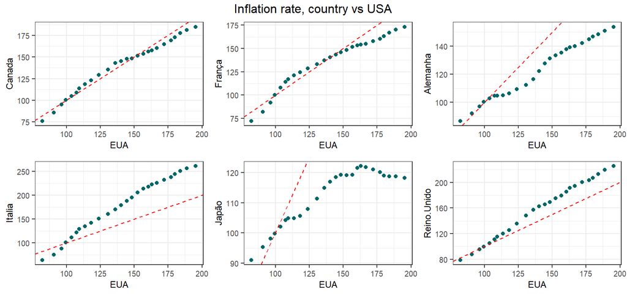

```r
can <- tbl_1.3 %>%
  ggplot(aes(x = EUA, y = Canada))+
  geom_point(color = graph_color)+
  geom_abline(intercept = 0, color = "red", lty = 2)+
  theme(title = element_text(size = title_size),
        axis.text = element_text(size = axis_size))

fra <- tbl_1.3 %>%
  ggplot(aes(x = EUA, y = França))+
  geom_point(color = graph_color)+
  geom_abline(intercept = 0, color = "red", lty = 2)+
  theme(title = element_text(size = title_size),
        axis.text = element_text(size = axis_size))

ale <- tbl_1.3 %>%
  ggplot(aes(x = EUA, y = Alemanha))+
  geom_point(color = graph_color)+
  geom_abline(intercept = 0, color = "red", lty = 2)+
  theme(title = element_text(size = title_size),
        axis.text = element_text(size = axis_size))

ita <- tbl_1.3 %>%
  ggplot(aes(x = EUA, y = Italia))+
  geom_point(color = graph_color)+
  geom_abline(intercept = 0, color = "red", lty = 2)+
  theme(title = element_text(size = title_size),
        axis.text = element_text(size = axis_size))

jap <- tbl_1.3 %>%
  ggplot(aes(x = EUA, y = Japão))+
  geom_point(color = graph_color)+
  geom_abline(intercept = 0, color = "red", lty = 2)+
  theme(title = element_text(size = title_size),
        axis.text = element_text(size = axis_size))

rei <- tbl_1.3 %>%
  ggplot(aes(x = EUA, y = Reino.Unido))+
  geom_point(color = graph_color)+
  geom_abline(intercept = 0, color = "red", lty = 2)+
  theme(title = element_text(size = title_size),
        axis.text = element_text(size = axis_size))


gridExtra::grid.arrange(can,fra,ale,ita,jap,rei,nrow = 2,ncol=3, top = textGrob("Inflation rate, country vs USA"))
```

```r
tbl_1.4 <- read.table(file = paste(path,"tabela_1.4_cambio.txt",sep = ""),
                      sep = " ",
                      header = T,
                      dec = ",",
                      )

# Ajustando a coluna do reino unido (1/taxa)
tbl_1.4 <-
  tbl_1.4 %>%
  mutate(Reino.unido = 1/Reino.unido)

# Amostra aleatório de 10 valores da tabela
tbl_1.4[sample(nrow(tbl_1.4),10), ]
```

|  | Ano | Australia | Canada | China | Japao | Mexico | Coreia.sul | Suecia | Suica | Reino.unido |
| --- | --- | --- | --- | --- | --- | --- | --- | --- | --- | --- |
| 6 | 1990 | 0.7807 | 1.1668 | 4.7921 | 145.00 | 2.813 | 710.64 | 5.9231 | 1.3901 | 0.5605067 |
| 12 | 1996 | 0.7828 | 1.3638 | 8.3389 | 108.78 | 7.600 | 805.00 | 6.7082 | 1.2361 | 0.6407381 |
| 18 | 2002 | 0.5437 | 1.5704 | 8.2771 | 125.22 | 9.663 | 1250.31 | 9.7233 | 1.5567 | 0.6655574 |
| 9 | 1993 | 0.6799 | 1.2902 | 5.7795 | 111.08 | 3.116 | 805.75 | 7.7956 | 1.4781 | 0.6659563 |
| 16 | 2000 | 0.5815 | 1.4855 | 8.2784 | 107.80 | 9.459 | 1130.90 | 9.1735 | 1.6904 | 0.6598047 |
| 4 | 1988 | 0.7841 | 1.2306 | 3.7314 | 128.17 | 2.273 | 734.52 | 6.1370 | 1.4643 | 0.5613878 |
| 11 | 1995 | 0.7407 | 1.3725 | 8.3700 | 93.96 | 6.447 | 772.69 | 7.1406 | 1.1812 | 0.6335128 |
| 5 | 1989 | 0.7919 | 1.1842 | 3.7673 | 138.07 | 2.461 | 674.13 | 6.4559 | 1.6369 | 0.6104261 |
| 8 | 1992 | 0.7352 | 1.2085 | 5.5206 | 126.78 | 3.095 | 784.66 | 5.8258 | 1.4064 | 0.5661552 |
| 7 | 1991 | 0.7787 | 1.1460 | 5.3337 | 134.59 | 3.018 | 736.73 | 6.0521 | 1.4356 | 0.5658029 |

##### **a) Represente graficamente a evolução das taxas de câmbio ao longo do tempo:**

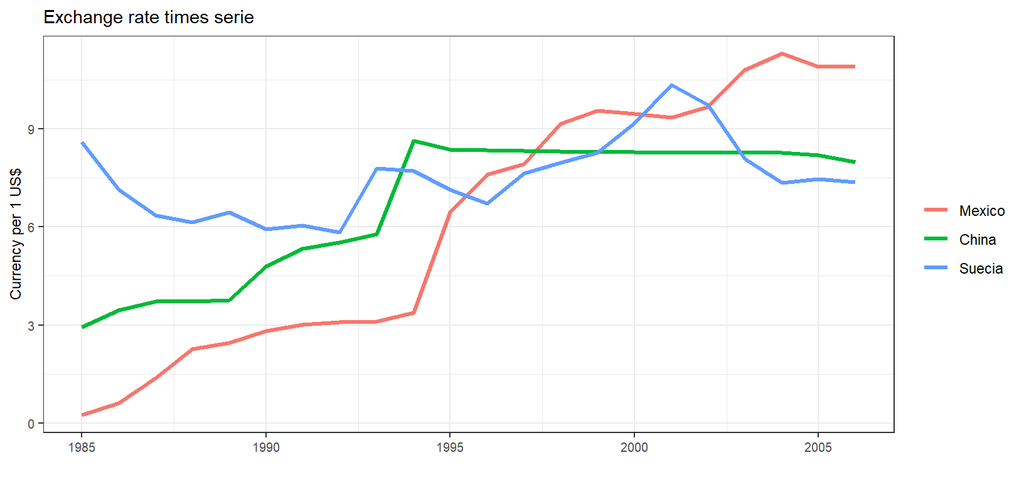

```r
tbl_1.4 %>%
  tidyr::gather("campo","valor",2:10) %>%
  filter(campo != "Coreia.sul",
         campo != "Japao",
         campo != "Suica",
         campo != "Reino.unido",
         campo != "Canada",
         campo != "Australia"
         ) %>%
  mutate(campo = fct_relevel(campo, levels = c("Mexico", "China", "Suecia"))) %>%
  ggplot(aes(x = Ano, y = valor,group = campo, color = campo))+
  geom_line(size = 1.2)+
  theme(title = element_text(size = title_size),
        axis.text = element_text(size = axis_size),
        legend.title = element_blank())+
  labs(title = "Exchange rate times serie",
       x = "",
       y = "Currency per 1 US$")
```

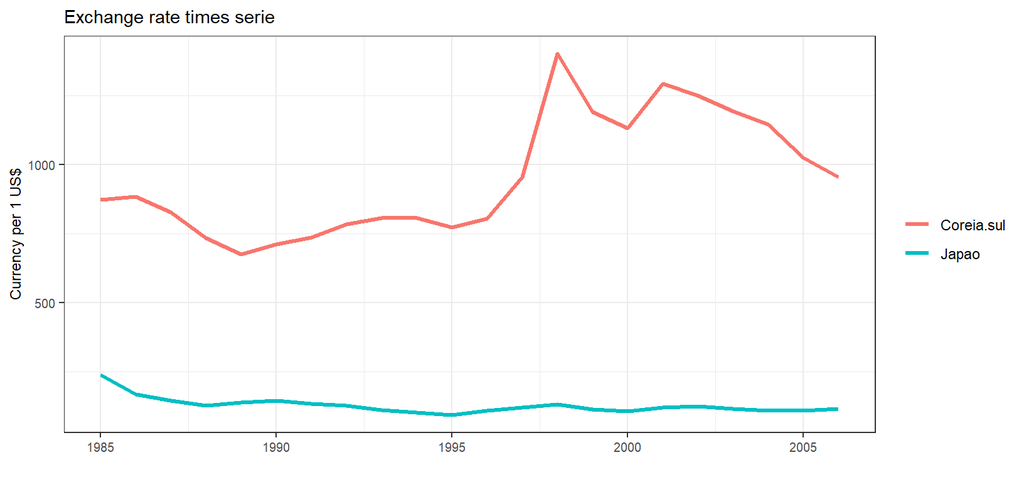

```r
tbl_1.4 %>%
  tidyr::gather("campo","valor",2:10) %>%
  filter(campo %in% c("Coreia.sul","Japao")) %>%
  ggplot(aes(x = Ano, y = valor, group = campo, color = campo))+
  geom_line(size = 1.2)+
  theme(title = element_text(size = title_size),
        axis.text = element_text(size = axis_size),
        legend.title = element_blank())+
  labs(title = "Exchange rate times serie",
       x = "",
       y = "Currency per 1 US$")
```

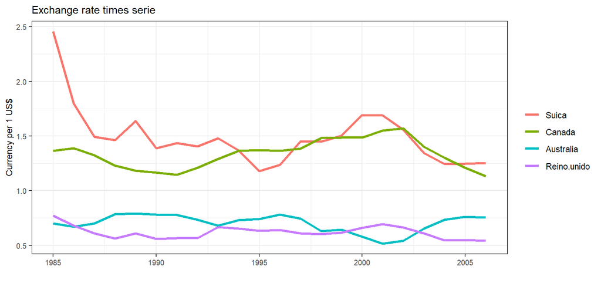

```r
tbl_1.4 %>%
  tidyr::gather("campo","valor",2:10) %>%
  filter(campo %in% c("Reino.unido","Canada","Australia","Suica")) %>%
  mutate(campo = fct_relevel(campo, levels = c("Suica", "Canada", "Australia", "Reino.unido"))) %>%
  ggplot(aes(x = Ano, y = valor, group = campo, color = campo))+
  geom_line(size = 1.2)+
  theme(title = element_text(size = title_size),
        axis.text = element_text(size = axis_size),
        legend.title = element_blank())+
  labs(title = "Exchange rate times serie",
       x = "",
       y = "Currency per 1 US$")
```

##### **1.7) A tabela abaixo apresenta o orçamento de publicidade com as impressões retidas (através de uma pesquisa feita com 4 mil adultos).**

```r
tbl_1.6 <- read.table(file = paste(path,"tabela_1.6_publicidade.txt",sep = ""),
                      sep = " ",
                      header = T,
                      dec = ","
                      )

# Amostra aleatória dos dados
tbl_1.6[sample(nrow(tbl_1.6),10), ]
```

|  | empresa | impressions | investment |
| --- | --- | --- | --- |
| 16 | Polaroid | 38.0 | 26.9 |
| 2 | Pepsi | 99.6 | 74.1 |
| 15 | Wendys | 29.2 | 49.7 |
| 19 | Oscar_Meyer | 23.4 | 9.2 |
| 20 | Crest | 71.1 | 32.4 |
| 10 | Ford | 40.1 | 166.2 |
| 7 | McDonald | 92.4 | 185.9 |
| 4 | Fed_Express | 21.9 | 22.9 |
| 3 | Stroh | 11.7 | 19.3 |
| 18 | Meow_Mix | 12.3 | 7.6 |

##### **a) Mostre a relação entre impressões e o investimento em publicidade.**

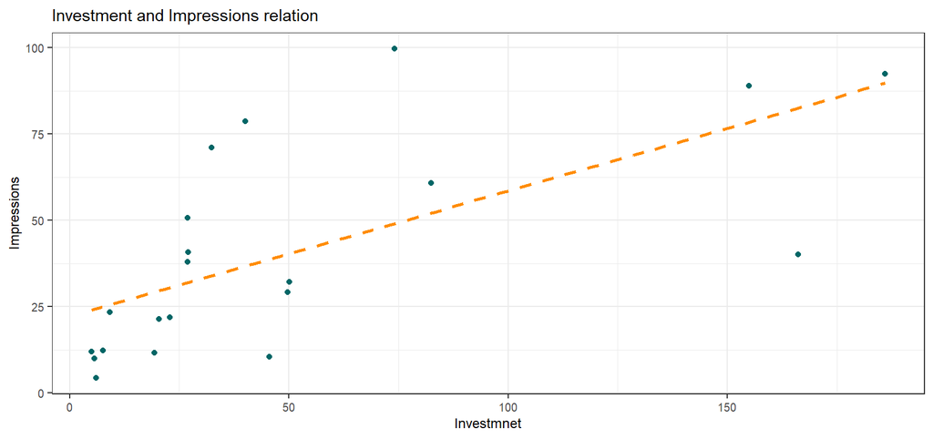

```r
tbl_1.6 %>%
  ggplot(aes(x = investment, y = impressions))+
  geom_point(color = graph_color)+
  geom_smooth(method = "lm", formula = y ~ x, se = F, lty = 20, color = "dark orange")+
  theme(title = element_text(size = title_size),
        axis.text = element_text(size = axis_size))+
  labs(title = "Investment and Impressions relation",
       x = "Investmnet",
       y = "Impressions")
```

### **2**

#### **Análise de regressão com duas variáveis: Algumas ideias básicas**

##### **Resumo**

Neste capítulo, os autores abordam de maneira mais aprofundada o modelo de regressão linear, introduzindo o coneito de **valor esperado de Y** condicional e incondicional. Indica-se que a essência do modelo de regressão é fornecer condições para o valor médio esperado da variável (Y) estudada, ou seja, o modelo de regressão irá gerar uma equação que explicará o valor médio desta variável Y.

Os autores também afirmam que o modelo de regressão buscará **estimar** funções de regressão populacional, fazendo uso de teorias (econômicas) e dados amostrais da população. Existe a função de regressão populacional (sendo apenas uma ideia abstrata) e a função de regressão amostral (que é criada no modelo de regressão), onde a regressão amostral é a responsável por gerar inferências sobre a populacional.

Por fim, os autores comentam sobre os erros estocásticos, que estão sempre presentes no modelo de regressão para representar todas variáveis não incluídas no modelo e ruídos aleatórios que não podem ser mapeados. A não inclusão de algumas variáveis no modelo é explicada no sentido de que isso é algo de certa forma positivo, pois é muito custoso coletar todas as variáveis e o aumento da complexidade do modelo não irá gerar aumento de performance de mesma magnitude. Outra ideia mencionada pelos autores referente aos erros estocásticos se refere à natureza aleatória do ser humano, que impacta a variável estudada **Y** e esta aleatoriedade será descrita nestes erros (**$\mu$**).

##### **2.14) Use a tabela abaixo com dados do EUA sobre o mercado de trabalho para responder as seguinter alternativas.**

```r
tbl_2.7 <- read.table(file = paste(path,"tabela_2.7_labour_market.txt",sep = ""),
                      sep = " ",
                      header = T,
                      dec = ","
                      )

# Amostra dos dados
tbl_2.7[sample(nrow(tbl_2.7),10), ]
```

|  | ano | share_men_work_force | share_women_work_force | unemployment_men | unemployment_women | avg_hourly_earning_men | avg_hourly_earning_women |
| --- | --- | --- | --- | --- | --- | --- | --- |
| 7 | 1986 | 76.3 | 55.3 | 6.9 | 7.1 | 7.96 | 8.92 |
| 16 | 1995 | 75.0 | 58.9 | 5.6 | 5.6 | 7.53 | 11.64 |
| 1 | 1980 | 77.4 | 51.5 | 6.9 | 7.4 | 7.99 | 6.84 |
| 2 | 1981 | 77.0 | 52.1 | 7.4 | 7.9 | 7.88 | 7.43 |
| 23 | 2002 | 74.1 | 59.6 | 5.9 | 5.6 | 8.24 | 14.95 |
| 20 | 1999 | 74.7 | 60.0 | 4.1 | 4.3 | 8.00 | 13.47 |
| 21 | 2000 | 74.8 | 59.9 | 3.9 | 4.1 | 8.03 | 14.00 |
| 14 | 1993 | 75.4 | 57.9 | 7.2 | 6.6 | 7.52 | 11.03 |
| 15 | 1994 | 75.1 | 58.8 | 6.2 | 6.0 | 7.53 | 11.32 |
| 6 | 1985 | 76.3 | 54.5 | 7.0 | 7.4 | 7.91 | 8.73 |

##### **a) Represente graficamente a relação entre a taxa de participação dos homens na força de trabalho e a taxa de desemprego dos homens.**

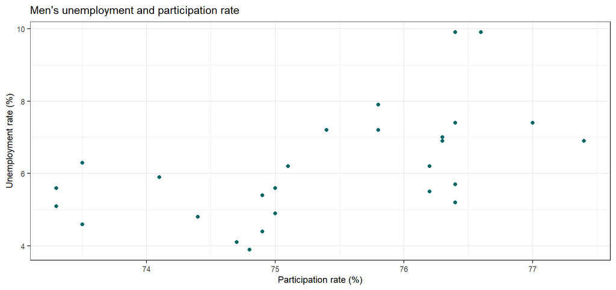

```r
women_df <-
  tbl_2.7 %>%
  select(share_women_work_force,unemployment_women) %>%
  transmute(
    share_work_force = share_women_work_force,
    unemployment = unemployment_women
  ) %>%
  mutate(type = "women")

tbl_2.7 %>%
  select(share_men_work_force,unemployment_men) %>%
  transmute(
    share_work_force = share_men_work_force,
    unemployment = unemployment_men
  ) %>%
  mutate(type = "men") %>%
  ggplot(aes(x=share_work_force,y=unemployment,color=type))+
  geom_point(color = graph_color)+
  theme(title = element_text(size = title_size),
        axis.text = element_text(size = axis_size),
        legend.title = element_blank(),
        legend.position = "none")+
  labs(title = "Men's unemployment and participation rate",
       x = "Participation rate (%)",
       y = "Unemployment rate (%)")
```

##### **c) Represente graficamente a taxa de participação de homens e mulheres em relação ao ganho médio por hora.**

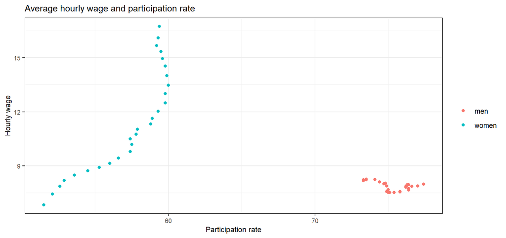

```r
women_df <-
  tbl_2.7 %>%
  select(share_women_work_force,avg_hourly_earning_women) %>%
  transmute(
    share_work_force = share_women_work_force,
    avg_hourly_earning = avg_hourly_earning_women
  ) %>%
  mutate(type = "women")

tbl_2.7 %>%
  select(share_men_work_force,avg_hourly_earning_men) %>%
  transmute(
    share_work_force = share_men_work_force,
    avg_hourly_earning = avg_hourly_earning_men
  ) %>%
  mutate(type = "men") %>%
  union_all(women_df) %>%
  ggplot(aes(x=share_work_force,y=avg_hourly_earning,color=type))+
  geom_point()+
  theme(title = element_text(size = title_size),
        axis.text = element_text(size = axis_size),
        legend.title = element_blank())+
  labs(title = "Average hourly wage and participation rate",
       x = "Participation rate",
       y = "Hourly wage")
```

##### **2.15) Use os dados da tabela 2.8, sobre despesa com alimentação e despesa total (em rupias), de uma amostra de 55 domicílios da Índia, para responder as alternativas abaixo.**

```r
tbl_2.8 <- read.table(file = paste(path,"tabela_2.8_despesa_india.txt",sep = ""),
                      sep = " ",
                      header = T,
                      dec = ",")

# Amostra dos dados
tbl_2.8[sample(nrow(tbl_2.8),10), ]
```

|  | alimento | total |
| --- | --- | --- |
| 32 | 322 | 677 |
| 55 | 295 | 695 |
| 52 | 450 | 720 |
| 23 | 420 | 627 |
| 30 | 385 | 662 |
| 39 | 380 | 785 |
| 31 | 470 | 663 |
| 22 | 267 | 623 |
| 35 | 305 | 801 |
| 24 | 300 | 630 |

##### **a) Represente graficamente os dados, colocando no eixo vertical as despesas com alimentação e no eixo horizontal os gastos totais e em seguida, insira uma linha de regressão.**

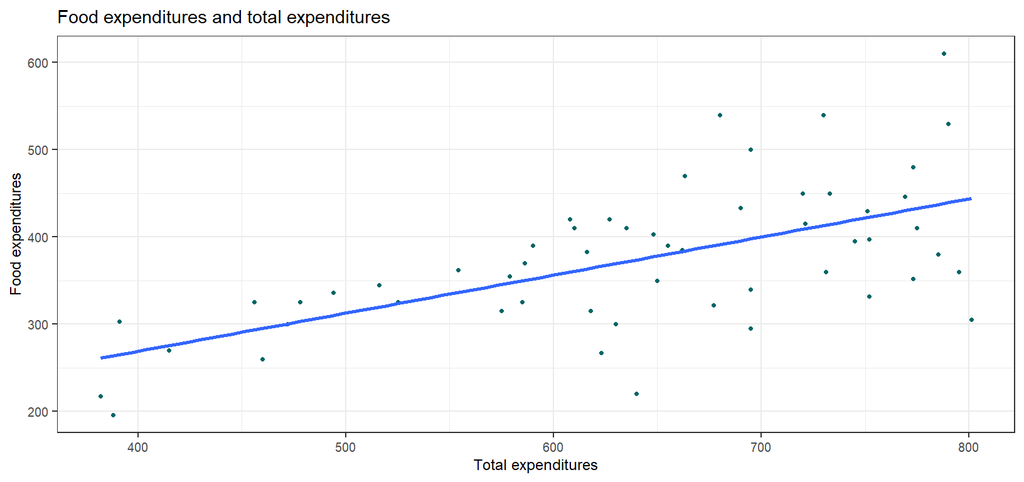

```r
tbl_2.8 %>%
  ggplot(aes(x = total, y = alimento))+
  geom_point(color = graph_color, shape = 20)+
  geom_smooth(method = "lm", se = F)+
  theme(title = element_text(size = title_size),
        axis.text = element_text(size = axis_size))+
  labs(title = "Food expenditures and total expenditures",
       x = "Total expenditures",
       y = "Food expenditures")
```

### **3**

#### **Modelo de regressão de duas variáveis: o problema da estimação**

#### **Resumo**

O objetivo neste capítulo será estimar a função de regressão populacional (FRP) com base na função de regressão amostral (FRA), da maneira mais precisa possível. Os métodos disponíveis para isso são (i) mínimos quadrados ordinários e (ii) máxima verossimilhança. O método (i) é o mais usado, por ser mais simples, porém ambos geram resultados semelhantes.

Os autores abordarão o método dos mínimos quadrados ordinários no detalhe, explicando como se chega a equação de geração dos parâmetros do modelo de regressão e o motivo por traz do “mínimo” presente no nome do método. Após explicarem as fórmulas do modelo, os autores comentam sobre as prioridades destes estimadores e as hipóteses presentes neste método. Como as hipóteses deste método são importantes para a geração de um modelo confiável, abaixo elas são descritas com maior detalhe.

**As hipóteses do método dos mínimos quadrados**

Como o objetivo não é só obter os parâmetros ($\beta_1$ e $\beta_2$) com base em uma amostra, mas sim o de obtê-los e realizar inferências sobre os parâmetros populacionais, se faz neessário estabelecer certas hipóteses a respeito de como a variável explicada / dependente é gerada.

Hipótese 1: O modelo de regressão linear é linear nos parâmeteos $\beta$, embora possa não ser linear nas variáveis (x), ou seja, o regressando Y e o regressor X podem não ser lineares e o modelo continuará sendo linear.

Hipótese 2: Existência de independência entre as variáveis X e o termo de erro. Esta independência se fundamenta na ideia de que os termos X e $\mu$ possuem influências separadas (e aditivas) sobre Y. Se caso estes termos foram correlacionados, não é possível avaliar efeitos individuais sobre Y. Caso estes termos sejam correlacionados é bem provável que o termo $\mu$ contenha uma variável importante no modelo que não foi incluída.

Hipótese 3: O valor médio do termo de erro $\mu$ deve ser zero. Esta hipótese indica que as variáveis não incluídas no modelo e consequentemente representadas por $\mu$ não devem afetar sistematicamente o valor médio de Y, ou seja, os valores positivos de $\mu$ cancelam os valores negativos. A hipótese 3 implica que não existe erro de especificação ou viés de especificação do modelo, que pode ocorrer quando alguma variável importante deixa de ser mapeada no modelo de regressão ou variáveis irrelevantes são incluídas.

Hipótese 4: Homocedasticidade de $\mu$. Este hipótese indica que a variância do termo de erro $\mu$ é a mesma independente do valor de X. Homocedasticidade é a constante variância do termo de erro.

Hipótese 5: Não há autocorrelação entre os termos de erro.

Hipótese 6: O número de observações n deve ser maior que o número de parâmetros a serem estimados, ou seja, o número de observações n deve ser maior que o números de variáveis explicativas.

Hipótese 7: Deve haver variabilidade dos valores de X. Isto também implica que não deve haver outliers ou valores discrepantes.

Por fim, há uma explicação sobre as medidas de precisão do modelo de regressão. Sendo elas o erro padrão dos estimadores e pelo coeficiente de determinação (R²) que indica a qualidade do ajuste da reta de regressão. Na mesma problemática de validação da precisão dos estimadores, há a técnica de Monte Carlo, que irá realizar simulações dos parâmetros calculados para verificar a consistência dos resultados e por fim aumentar a confiabilidade do parâmetro.

#### **Exercícios**

##### **3.18) Na tabela abaixo consta a classificação de dez estudantes nas provas parcial e final de estatística. Calcule o coeficiente de correlação de ranking de Spearman e interprete os resultados.**

```r
df_3.18 <- data.frame(
  prova_parcial = c(1,3,7,10,9,5,4,8,2,6),
  prova_final = c(3,2,8,7,9,6,5,10,1,4)
)

#Amostra aleatória dos dados
df_3.18[sample(nrow(df_3.18),10), ]
```

|  | prova_parcial | prova_final |
| --- | --- | --- |
| 2 | 3 | 2 |
| 7 | 4 | 5 |
| 8 | 8 | 10 |
| 10 | 6 | 4 |
| 4 | 10 | 7 |
| 9 | 2 | 1 |
| 5 | 9 | 9 |
| 6 | 5 | 6 |
| 1 | 1 | 3 |
| 3 | 7 | 8 |

```r
# Coeficiente de correlação de spearman
cor.test(df_3.18$prova_parcial,df_3.18$prova_final,method = "spearman") %>% pander()
```

Spearman’s rank correlation rho: `df_3.18$prova_parcial` and `df_3.18$prova_final`

| Test statistic | P value | Alternative hypothesis | rho |
| --- | --- | --- | --- |
| 26 | 0.004459 * * | two.sided | 0.8424 |

##### **3.19) A equação abaixo mostra a relação entre a taxa de câmbio e a inflação para o Canadá e Estados Unidos para o período de 1985 e 2005**

$\widehat{Y_t} = 0.912 + 2.25X_t$

Onde:

$\widehat{Y_t}$ = DC/US$ (taxa de câmbio do Canadá em relação ao Dólar)

$X_t$ = inflação americana / inflação do canadá

##### **b) O valor positivo de X faz sentido econômico?**

R: Acredito que não, pois a inflação maior no EUA deveria reduzir a taxa de câmbio do Canadá e não aumentá-la. Desta forma, o valor de X deveria ser negativo.

##### **3.20) A tabela abaixo apresenta dados do índice de produção por hora (X) e remuneração real por hora (Y) para os setores empresarial e empresarial não agrícola, entre 1960 e 2005. O ano base é 1992 = 100.**

```r
tbl_3.6 <- read.table(file = paste(path,"tabela_3.6_produtividade_e_salario.txt",sep = ""),
                      sep = " ",
                      header = T,
                      dec = ",",
                      )

tbl_3.6[sample(nrow(tbl_3.6),10), ]
```

|  | ano | prod_setor_empresarial | prod_setor_n_agricola | sal_setor_empresarial | sal_setor_n_agricola |
| --- | --- | --- | --- | --- | --- |
| 20 | 1979 | 79.3 | 80.7 | 89.3 | 89.7 |
| 24 | 1983 | 83.0 | 84.5 | 90.3 | 90.9 |
| 17 | 1976 | 77.1 | 78.7 | 86.4 | 86.6 |
| 43 | 2002 | 124.0 | 123.5 | 115.7 | 115.1 |
| 8 | 1967 | 62.5 | 64.7 | 73.5 | 74.5 |
| 42 | 2001 | 119.1 | 118.6 | 113.5 | 112.8 |
| 14 | 1973 | 73.4 | 75.3 | 84.3 | 84.7 |
| 5 | 1964 | 56.8 | 59.6 | 67.7 | 69.3 |
| 2 | 1961 | 50.6 | 53.5 | 62.5 | 64.8 |
| 40 | 1999 | 112.8 | 112.5 | 108.0 | 107.5 |

##### **a) Represente graficamente Y contra X para os dois setores da economia separadamente.**

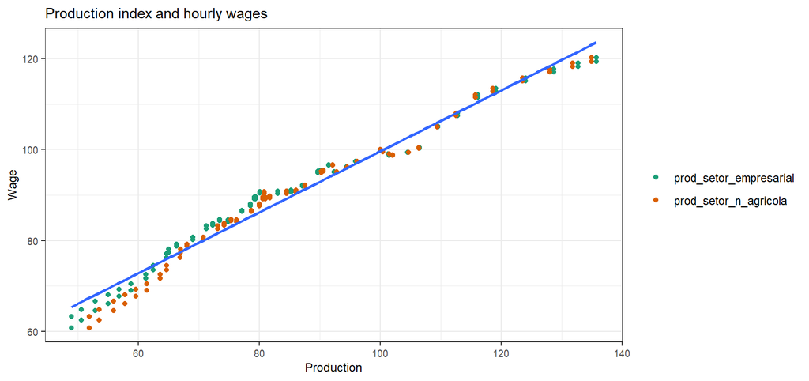

```r
tbl_3.6 %>%
  tidyr::gather("production","prod",2:3) %>%
  tidyr::gather("wage","wag",2:3) %>%
  ggplot()+
  geom_point(aes(x = prod, y = wag, color = production))+
  scale_color_brewer(palette = "Dark2")+
  geom_smooth(aes(x = prod, y = wag), method = "lm",se = F)+
  theme(title = element_text(size = title_size),
        axis.text = element_text(size = axis_size),
        legend.title = element_blank())+
  labs(title = "Production index and hourly wages",
       x = "Production",
       y = "Wage")
```

##### **c) Estime uma regressão de MQO de Y contra X.**

```r
tbl_3.6 %>%
  tidyr::gather("production","X",2:3) %>%
  tidyr::gather("wage","Y",2:3) -> df_tbl_3.6

summary(lm(Y~X, data = df_tbl_3.6)) %>% pander()
```

|  | Estimate | Std. Error | t value | Pr(>\|t\|) |
| --- | --- | --- | --- | --- |
| **(Intercept)** | 32.63 | 0.7125 | 45.8 | 7.626e-102 |
| **X** | 0.6699 | 0.007976 | 83.99 | 1.675e-147 |

Fitting linear model: Y ~ X

| Observations | Residual Std. Error | $R^2$ | Adjusted $R^2$ |
| --- | --- | --- | --- |
| 184 | 2.37 | 0.9749 | 0.9747 |

##### **3.22) A tabela abaixo mostra o preço do ouro, o índice NYSE e o índice IPC entre 1974 e 2006. Use-a para responder as alternativas abaixo:**

```r
tbl_3.7 <- read.table(file =
                      paste(path,"tabela_3.7_ouro_nyse_IPC.txt",sep = ""),
                      sep = " ",
                      header = T,
                      dec = ",",
                      )

# Amostra aleatória dos dados
tbl_3.7[sample(nrow(tbl_3.7),10), ]
```

|  | ano | gold_price | nyse_index | ipc_index |
| --- | --- | --- | --- | --- |
| 8 | 1981 | 460.03 | 782.62 | 90.9 |
| 30 | 2003 | 363.38 | 5447.46 | 184.0 |
| 26 | 1999 | 278.88 | 6546.81 | 166.6 |
| 13 | 1986 | 367.66 | 1438.02 | 109.6 |
| 12 | 1985 | 317.26 | 1142.97 | 107.6 |
| 27 | 2000 | 279.11 | 6805.89 | 172.2 |
| 33 | 2006 | 603.46 | 8357.99 | 201.6 |
| 24 | 1997 | 331.02 | 4827.35 | 160.5 |
| 11 | 1984 | 360.48 | 977.33 | 103.9 |
| 6 | 1979 | 306.68 | 616.68 | 72.6 |

##### **a) Assinale, em um mesmo diagrama de dispersão, os preços do ouro, o IPC e o índice NYSE.**

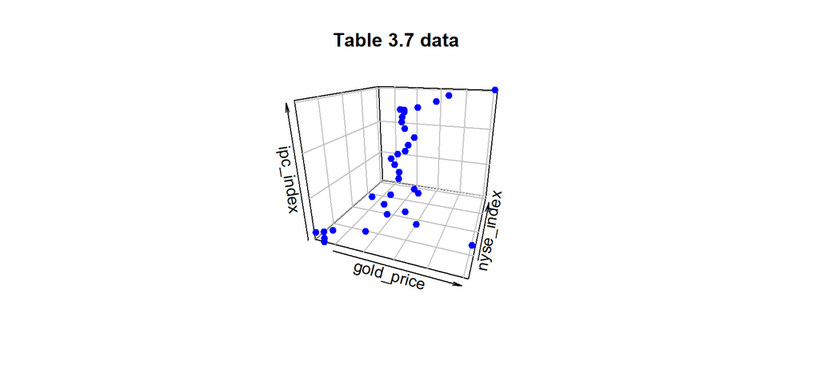

```r
tbl_3.7 %>%
  transmute(x = gold_price,
         y = nyse_index,
         z = ipc_index) -> df_test

x <- df_test$x
y <- df_test$y
z <- df_test$z

plot3D::scatter3D(x, y, z, colvar = NULL, add = FALSE, col = "blue", pch = 19, phi = 20, theta = 20, cex = .9, bty = "b2", expand = .9, col.grid = "darkblue", col.panel = "steelblue", colkey = T, main = "Table 3.7 data", xlab = "gold_price", ylab = "nyse_index", zlab = "ipc_index")
```

##### **b) Supõe-se que um investimento funcione como proteção contra a inflação se seu preço ou sua taxa de retorno acompanha, pelo menos, a taxa de inflação. Para testar esta hipótese, ajuste o seguinte modelo, supondo que o diagrama de dispersão elaborado no item (a) seja adequado.**

$$gold.price = \beta_1 + \beta_2 + IPC + \mu$$
$$NYSE.index = \beta_1 + \beta_2 + IPC + \mu$$
R: Para testar está hipótese se faz necessário analisar a taxa de variação destes indicadores e ver se a variação do outro e do índice NYSE fica acima da variação do IPC, que representa a inflação para o consumidor.

```r
tbl_3.7 %>%
  mutate(gold_price_var = round(gold_price/lag(gold_price, 1, default = NA), digits = 8)-1,
         nyse_index_var = round(nyse_index/lag(nyse_index, 1, default = NA), digits = 8)-1,
         ipc_index_var = round(ipc_index/lag(ipc_index, 1, default = NA), digits = 8)-1) %>%
  filter(!is.na(gold_price_var)) -> tbl_3.7_df_adj

# Modelo 1, gold_price ~ ipc_index
tbl_3.7_df_adj %>% lm(formula = gold_price_var ~ ipc_index_var) %>% pander()
```

Fitting linear model: gold_price_var ~ ipc_index_var

|  | Estimate | Std. Error | t value | Pr(>\|t\|) |
| --- | --- | --- | --- | --- |
| **(Intercept)** | -0.1147 | 0.07197 | -1.594 | 0.1215 |
| **ipc_index_var** | 3.96 | 1.337 | 2.962 | 0.005932 |

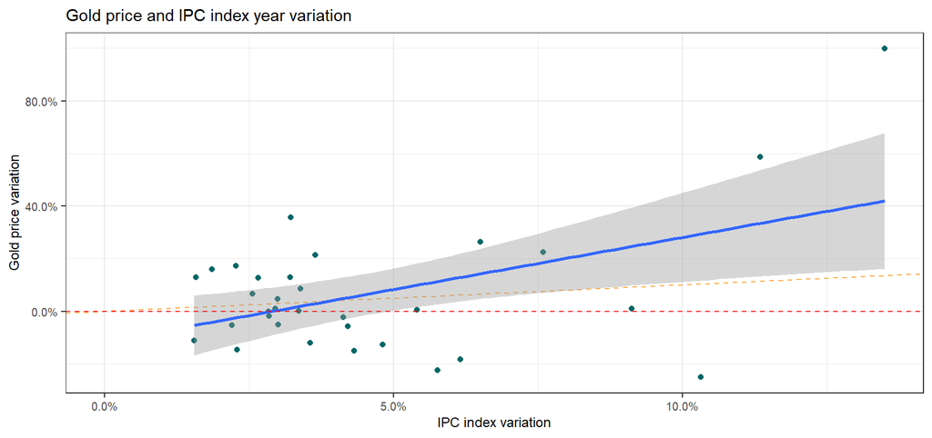

```r
tbl_3.7_df_adj %>%
  ggplot()+
  geom_point(aes(x = ipc_index_var, y = gold_price_var), color = graph_color)+
  geom_abline(lty = 2, color = "dark orange", alpha = .7)+
  geom_smooth(aes(x = ipc_index_var, y = gold_price_var), method = "lm", formula = y ~ x)+
  geom_hline(yintercept = 0, lty = 2, color = "red", alpha = .8)+
  expand_limits(x = 0, y = 0)+
  scale_x_continuous(labels = scales::percent)+
  scale_y_continuous(labels = scales::percent)+
  theme(title = element_text(size = title_size),
        axis.text = element_text(size = axis_size))+
  labs(title = "Gold price and IPC index year variation",
       x = "IPC index variation",
       y = "Gold price variation")
```

```r
# Modelo 2, nyse_index ~ ipc_index
tbl_3.7_df_adj %>% lm(formula = nyse_index_var ~ ipc_index_var) %>% pander()
```

Fitting linear model: nyse_index_var ~ ipc_index_var

|  | Estimate | Std. Error | t value | Pr(>\|t\|) |
| --- | --- | --- | --- | --- |
| **(Intercept)** | 0.1213 | 0.03777 | 3.21 | 0.003156 |
| **ipc_index_var** | -0.4604 | 0.7017 | -0.6561 | 0.5168 |

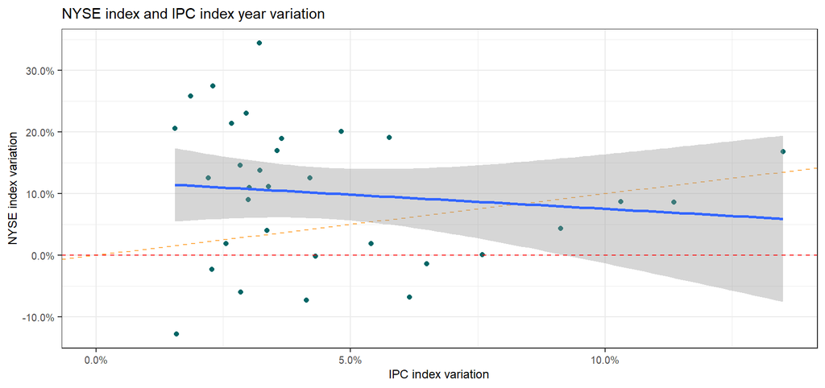

```r
tbl_3.7_df_adj %>%
  ggplot()+
  geom_point(aes(x = ipc_index_var, y = nyse_index_var), color = graph_color)+
  geom_abline(lty = 2, color = "dark orange", alpha = .7)+
  geom_smooth(aes(x = ipc_index_var, y = nyse_index_var), method = "lm", formula = y ~ x)+
  geom_hline(yintercept = 0, lty = 2, color = "red", alpha = .8)+
  expand_limits(x = 0, y = 0)+
  scale_x_continuous(labels = scales::percent)+
  scale_y_continuous(labels = scales::percent)+
  theme(title = element_text(size = title_size),
        axis.text = element_text(size = axis_size))+
  labs(title = "NYSE index and IPC index year variation",
       x = "IPC index variation",
       y = "NYSE index variation")
```

Aparentemente, o ouro é um ativo mais interessante para edge do que o índice NYSE, porém há dois outliers do preço do ouro que está fazendo a regressão gerar um parâmetro positivo.

### **4**

#### **Modelo clássico de regressão linear normal**

##### **Resumo**

Este capítulo é focado no modelo clássico de regressão linear normal que introduz o conceito de distribuição normal dos termos de erro. A ideia é que, como dito anteriormente, o objetivo do modelo de regressão é gerar estimadores ($\hat{\beta}$) para o parâmetro populacional ($\beta$) e como se está falando sobre estimadores, conclui-se que eles irão variar de amostra para amostra, ou seja, são variáveis aleatórias que deverão seguir alguma distribuição de probabilidade.

Quando se indica que os estimadores devem seguir uma distribuição de probabilidade, a mais cogitada é a normal. Para afirmar que os estimadores seguirão a distribuição normal, os autores mostrma algebricamente que os estimadores seguem uma função linear do termo de erro $\mu$ e sabendo que quando uma variável é uma função linear de outra que segue comportamento aleatório e com distribuição normal, pode-se assumir que a primeira também terá comportamento aleatório de mesma distribuição. Desta forma, cria-se a hipótese de normalidade dos resíduos (a.k.a termo de erro $\mu$) e consequentemente a hipótese de normalidade dos estimadores ($\hat{\beta}$), que embasará inferências (teste de hipóteses e intervalos de confiança), pilar fundamental do modelo clássico.

A hipótese de normalidade dos resíduos, pode ser fundamentado no **teorema do limite central**. Pelo fato de que os resíduos representam diversas variáveis não inclusas no modelo, há a ideia de que quando diversas variáveis são representadas por uma únida e suas distribuições de probabilidade consolidadas (somadas), o resultado será uma distribuição normal. Ao formar esta hipótese do modelo, pode-se realizar testes estatísticos (t, F, x²) dos estimadores para inferir sobre o verdadeiro valor dos parâmetros populacionais.

### **5**

#### **A regressão de duas variáveis: estimação de intervalo e teste de hipóteses**